# estadística

Ana Letycia

10/12/2021

# Análises estatadísticas básicas en R

## Estadísticas descritivas básicas de los datos

```r
felicidad = read.csv("tabelas/felicidad_red.csv")
```

```r
felicidad
```

```
##                         Pais                             Region
## 1                   Slovakia         Central and Eastern Europe
## 2                   Slovenia         Central and Eastern Europe
## 3                  Lithuania         Central and Eastern Europe
## 4                    Albania         Central and Eastern Europe
## 5                 Uzbekistan Commonwealth of Independent States
## 6                 Azerbaijan Commonwealth of Independent States
## 7                     Russia Commonwealth of Independent States
## 8                    Moldova Commonwealth of Independent States
## 9   Taiwan Province of China                          East Asia
## 10                     China                          East Asia
## 11                  Mongolia                          East Asia
## 12 Hong Kong S.A.R. of China                          East Asia
## 13                 Argentina        Latin America and Caribbean
## 14                     Haiti        Latin America and Caribbean
```

[output cut: 108 more lines]

Vamos evaluar la variable Indice_felicidad:

Podemos ordenar la tabla por el indice de felicidad

```r
felicidad[order(felicidad$Indice_felicidad),]
```

```
##                         Pais                             Region
## 25               Afghanistan                         South Asia
## 34                  Zimbabwe                 Sub-Saharan Africa
## 14                     Haiti        Latin America and Caribbean
## 27                     India                         South Asia
## 35                Mauritania                 Sub-Saharan Africa
## 28                 Sri Lanka                         South Asia
## 20                    Jordan       Middle East and North Africa
## 31                   Myanmar                     Southeast Asia
## 18                   Tunisia       Middle East and North Africa
## 30                  Cambodia                     Southeast Asia
## 17                      Iraq       Middle East and North Africa
## 36              South Africa                 Sub-Saharan Africa
## 4                    Albania         Central and Eastern Europe
## 6                 Azerbaijan Commonwealth of Independent States
```

[output cut: 108 more lines]

```r
dim(felicidad)
```

```
## [1] 40  8
```

Resumen estadístico

```r
summary(felicidad)
```

```
##      Pais              Region          Indice_felicidad Suporte_social
##  Length:40          Length:40          Min.   :2.523    Min.   :0.4630
##  Class :character   Class :character   1st Qu.:4.848    1st Qu.:0.7778
##  Mode  :character   Mode  :character   Median :5.721    Median :0.8535
##                                        Mean   :5.592    Mean   :0.8330
##                                        3rd Qu.:6.441    3rd Qu.:0.9215
##                                        Max.   :7.620    Max.   :0.9540
##  Expectativa_de_vida Liberdad_de_escojas  Generosidad
##  Min.   :52.49       Min.   :0.3820      Min.   :-0.2440
##  1st Qu.:62.38       1st Qu.:0.7535      1st Qu.:-0.1143
##  Median :67.10       Median :0.8390      Median :-0.0535
##  Mean   :66.31       Mean   :0.8125      Mean   :-0.0115
##  3rd Qu.:69.59       3rd Qu.:0.9095      3rd Qu.: 0.0815
##  Max.   :76.82       Max.   :0.9700      Max.   : 0.5090
##  Percepcion_de_corrupcion
##  Min.   :0.1790
##  1st Qu.:0.6780
##  Median :0.7745
##  Mean   :0.7109
##  3rd Qu.:0.8478
##  Max.   :0.9240
```

Media

```r
mean(felicidad$Indice_felicidad)
```

```
## [1] 5.59195
```

```r
median(felicidad$Indice_felicidad)
```

```
## [1] 5.7205
```

```r
var(felicidad$Indice_felicidad)
```

```
## [1] 1.471543
```

```r
range(felicidad$Indice_felicidad)
```

```
## [1] 2.523 7.620
```

El media de felicidad de todas las regiones

```r
aggregate(Indice_felicidad ~ Region, data = felicidad, FUN = mean)
```

```
##                                Region Indice_felicidad
## 1          Central and Eastern Europe          6.04100
## 2  Commonwealth of Independent States          5.64825
## 3                           East Asia          5.76925
## 4         Latin America and Caribbean          5.43575
## 5        Middle East and North Africa          5.08475
## 6               North America and ANZ          7.12850
## 7                          South Asia          3.98400
## 8                      Southeast Asia          5.13675
## 9                  Sub-Saharan Africa          4.59425
## 10                     Western Europe          7.09700
```

```r
aggregate(Indice_felicidad ~ Region, data = felicidad, FUN = sd)
```

```
##                                Region Indice_felicidad
## 1          Central and Eastern Europe        0.6218446
## 2  Commonwealth of Independent States        0.4292065
## 3                           East Asia        0.5606106
## 4         Latin America and Caribbean        1.2469529
## 5        Middle East and North Africa        0.9580993
## 6               North America and ANZ        0.1380568
## 7                          South Asia        1.1444434
## 8                      Southeast Asia        0.6395036
## 9                  Sub-Saharan Africa        1.2223418
## 10                     Western Europe        0.7940760
```

# Prueba de hipotesis

Una hipótesis es una suposición que se hace sobre algo en una condición. Generalmente, se refiere a un hecho común o a un hecho ya aceptado.

La hipótesis nula se refiere a que cualquier cambio que se produzca en un objeto de estudio se debe al azar y no hay ningún efecto específico. Por lo tanto, se considera, por ejemplo, que las medias serán iguales, aunque las condiciones sean diferentes.

La hipótesis alternativa indica que el cambio en el objeto de estudio puede deberse a alguna condición específica y no solo al azar. Por los tanto, la hipótesis alternativa considera que la media del fenómeno en la condición 1 es diferente de la media del fenómeno en la condición 2.

Las pruebas de hipótesis nos permiten realizar comparaciones para tomar la decisión de rechazar o no la hipótesis nula y decir si una alteración que se produce en nuestro objeto de estudio se debe al azar o si hay algún factor específico que influye en estas alteraciones. .

## Evaluando la normalid de los datos

```r
shapiro.test(felicidad$Indice_felicidad)   # (Shapiro-Wilk)
```

```
##
##  Shapiro-Wilk normality test
##
## data:  felicidad$Indice_felicidad
## W = 0.97915, p-value = 0.658
```

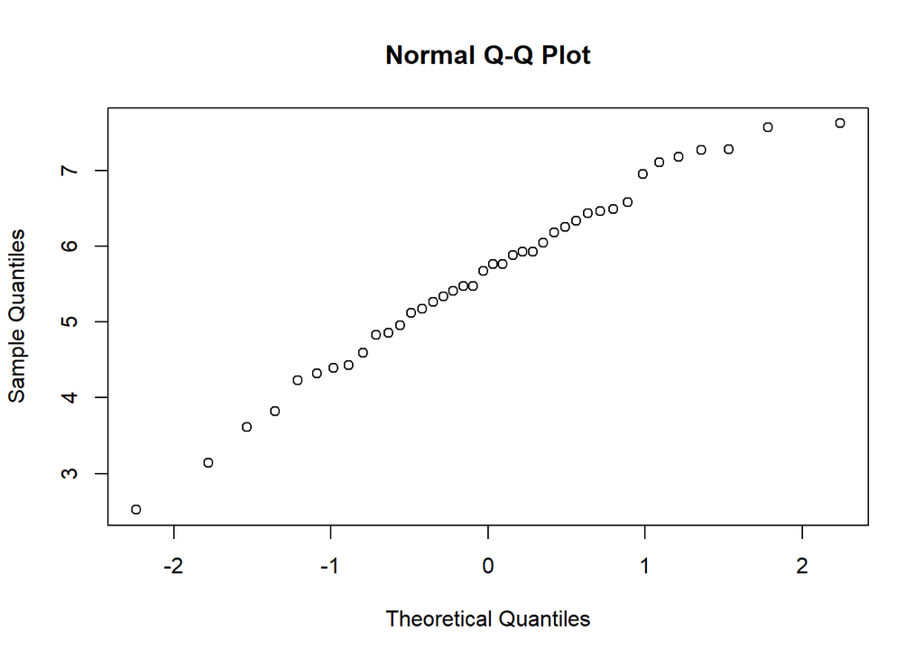

```r
qqnorm(felicidad$Indice_felicidad)         # Q-Q plot
```

## Intervalo de confianza

```r
ic_95_med = t.test(felicidad$Indice_felicidad, conf.level=.95)
ic_95_med
```

```
##
##  One Sample t-test
##
## data:  felicidad$Indice_felicidad
## t = 29.155, df = 39, p-value < 2.2e-16
## alternative hypothesis: true mean is not equal to 0
## 95 percent confidence interval:
##  5.203991 5.979909
## sample estimates:
## mean of x
##   5.59195
```

## Análisis de varianza

Existen varios métodos para comprobar las hipótesis. Aquí hablaremos del **análisis de la varianza**. Con este análisis es posible definir qué variables tienen un efecto significativo sobre el objeto de estudio. La decisión de rechazar o no la hipótesis nula, se hace con base en un valor p comparado con un valor de confianza, que se llama alfa.

La **análisis de varianza** permite comparar varios grupos al mismo tiempo para un mismo efecto y asume que el azar solo produce pequeñas desviaciones, mientras que las grandes diferencias son generadas por causas reales.

### Suposiciones de la análise de varianza

- Las variables son independientes dentre si
- Las distribuiciones de cada variable (y de los errores) se aproxima de una distribuición normal
- Las varianzas de cada variable son aproximadament iguales
- La variable dependiente es contínua

Comprobaremos la hipótesis nula de que todas las regiones del mundo tienen índices de felicidad similares, es decir, que cualquier variación en el índice se debe al azar y no al efecto de la región en la que se encuentra un país.

Creando un modelo matematico:

```r
modelo = lm(felicidad$Indice_felicidad ~ felicidad$Region)
```

```r
modelo
```

```
##
## Call:
## lm(formula = felicidad$Indice_felicidad ~ felicidad$Region)
##
## Coefficients:
##                                        (Intercept)
##                                             6.0410
## felicidad$RegionCommonwealth of Independent States
##                                            -0.3928
##                          felicidad$RegionEast Asia
##                                            -0.2718
##        felicidad$RegionLatin America and Caribbean
##                                            -0.6053
##       felicidad$RegionMiddle East and North Africa
##                                            -0.9562
##              felicidad$RegionNorth America and ANZ
##                                             1.0875
##                         felicidad$RegionSouth Asia
##                                            -2.0570
##                     felicidad$RegionSoutheast Asia
##                                            -0.9043
##                 felicidad$RegionSub-Saharan Africa
##                                            -1.4468
##                     felicidad$RegionWestern Europe
##                                             1.0560
```

### Diagnóstico del modelo

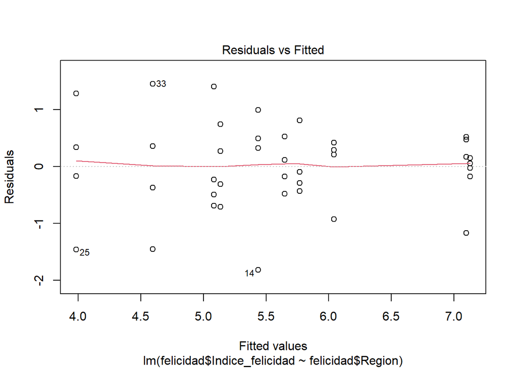

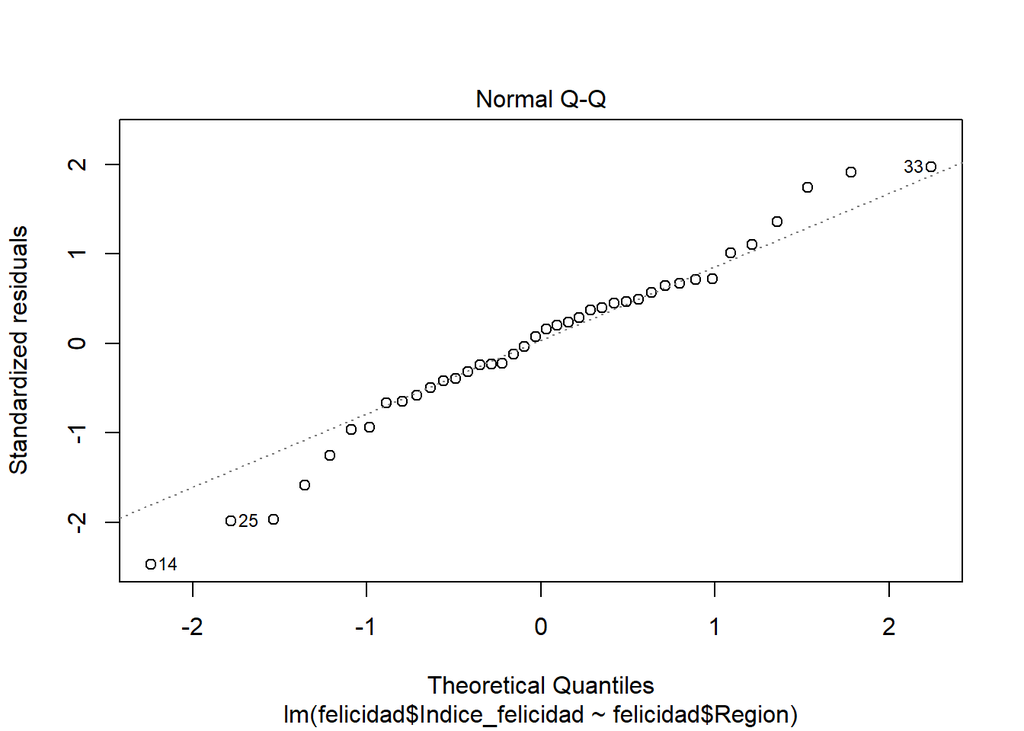

```
## hat values (leverages) are all = 0.25
##  and there are no factor predictors; no plot no. 5
```

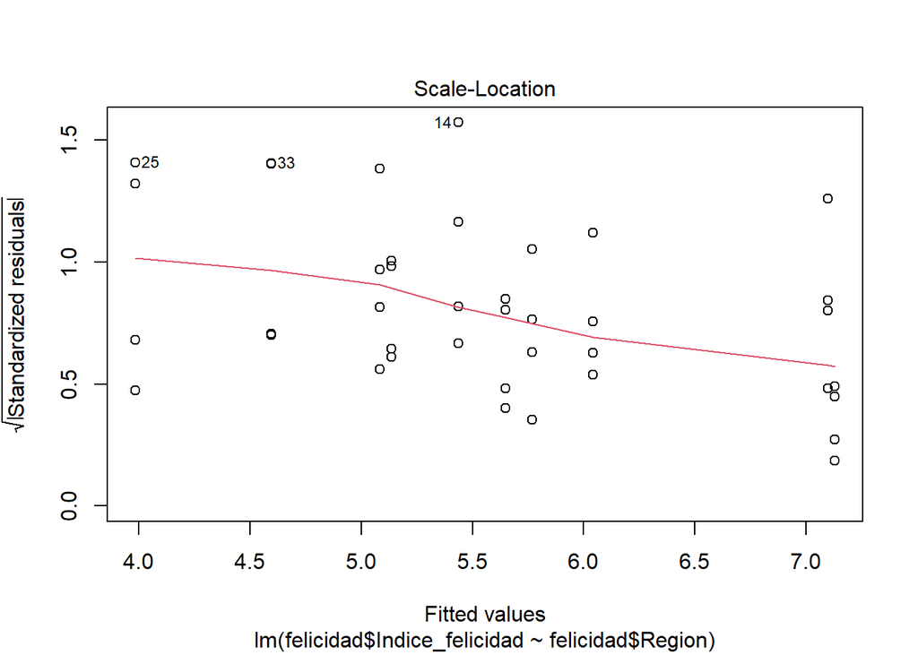

```r
plot(modelo)
```

## La analisis de varianza

```r
anova(modelo)
```

```
## Analysis of Variance Table
##
## Response: felicidad$Indice_felicidad
##                  Df Sum Sq Mean Sq F value    Pr(>F)
## felicidad$Region  9 35.729  3.9699   5.498 0.0001786 ***
## Residuals        30 21.661  0.7220
## ---
## Signif. codes:  0 '***' 0.001 '**' 0.01 '*' 0.05 '.' 0.1 ' ' 1
```

# Test de Tukey (comparación de las médias en pares)

Para hacer la prueba de medias utilizando el test de Tukey, vamos utizar una función del paquete *agricolae*. Para eso, instale el paquele con la función `install.packages()`

```r
library(agricolae)
```

```r
tukey = HSD.test(modelo, 'felicidad$Region', alpha = 0.05)
tukey
```

```
## $statistics
##    MSerror Df    Mean       CV     MSD
##   0.722049 30 5.59195 15.19568 2.04962
##
## $parameters
##    test           name.t ntr StudentizedRange alpha
##   Tukey felicidad$Region  10         4.824141  0.05
##
## $means
##                                    felicidad$Indice_felicidad       std r   Min
## Central and Eastern Europe                            6.04100 0.6218446 4 5.117
## Commonwealth of Independent States                    5.64825 0.4292065 4 5.171
## East Asia                                             5.76925 0.5606106 4 5.339
## Latin America and Caribbean                           5.43575 1.2469529 4 3.615
## Middle East and North Africa                          5.08475 0.9580993 4 4.395
## North America and ANZ                                 7.12850 0.1380568 4 6.951
## South Asia                                            3.98400 1.1444434 4 2.523
## Southeast Asia                                        5.13675 0.6395036 4 4.426
## Sub-Saharan Africa                                    4.59425 1.2223418 4 3.145
## Western Europe                                        7.09700 0.7940760 4 5.929
##                                      Max     Q25    Q50     Q75
## Central and Eastern Europe         6.461 5.97050 6.2930 6.36350
## Commonwealth of Independent States 6.179 5.40050 5.6215 5.86925
## East Asia                          6.584 5.44250 5.5770 5.90375
## Latin America and Caribbean        6.435 5.22675 5.8465 6.05550
## Middle East and North Africa       6.494 4.54575 4.7250 5.26400
## North America and ANZ              7.277 7.06500 7.1430 7.20650
## South Asia                         5.269 3.49500 4.0720 4.56100
## Southeast Asia                     5.880 4.72900 5.1205 5.52825
## Sub-Saharan Africa                 6.049 3.95650 4.5915 5.22925
## Western Europe                     7.620 6.93325 7.4195 7.58325
##
## $comparison
## NULL
##
## $groups
##                                    felicidad$Indice_felicidad groups
## North America and ANZ                                 7.12850      a
## Western Europe                                        7.09700      a
## Central and Eastern Europe                            6.04100     ab
## East Asia                                             5.76925    abc
## Commonwealth of Independent States                    5.64825    abc
## Latin America and Caribbean                           5.43575    abc
## Southeast Asia                                        5.13675    abc
## Middle East and North Africa                          5.08475    abc
## Sub-Saharan Africa                                    4.59425     bc
## South Asia                                            3.98400      c
##
## attr(,"class")
## [1] "group"
```